# Lab 3 Final

Author

Harshini Karthikeyan

Published

December 3, 2022

#### REVISIONS

Set Up/Formatting:

For the first two code chunks I added in “message = FALSE” to remove the message. I noticed the demographics code chunk had an unnecessary message pop up as well and I fixed that. Additionally, this wasn’t addressed in this lab’s revisions, it was in Lab 4. However, I had put read.csv here, but somehow neither of us caught it previously. I have now switched that to read_csv().

1. I did not add enough information summarizing the data set, so I have gone in and added more, regarding how data was collected and from whom.

4. I hadn’t used the most efficient code to clean the data, therefore I added an across function, to make it so that I have less lines of repetitive code.

# Lab 3

Set Up:

```r
library(tidyverse)
```

```r
hiphop <- read_csv(here::here("supporting_artifacts",
                                    "Labs", "Lab_3_Final",
                              "hiphop.csv"))
dim(hiphop)
```

```
[1] 10752    38
```

1. The hip-hop data set has 10752 rows and 38 columns. It is a data set used to measure how accurately individuals knew and how familiar they were with the definitions to AAE vocabulary words. They were given a self-identifying demographic questionnaire and the data set provides that information as well. This study was conducted on undergraduate students currently in classes on linguistics, sociology and music, in the University of Minnesota. There were a 168 participants from the above category in the study, and of those 166 who were not African-American were analyzed. The free-form responses of individuals were coded into a scale of 1 to 5 , one indicating less(knowledge or preference for genre) and 5 indicating greater awareness.
2. Each row is person’s answer to how familiar they feel with each of the 64 words. It would be more manageable if their responses were all in the same row however.
3. Missing values were replaced with the mean. However, as this is a sample it is not fully representative of the population mean. Replacing missing values with the sample mean could shift the overall data further from the true mean and decrease the standard deviation.

```r
hiphop_clean <- hiphop |>
  mutate(across(.cols = c(sex, subj, ethnic),
                          ~as.factor(.)))
```

5. 64 unique words

```r
hiphop |>
  distinct(word, .keep_all = TRUE) |>
  count()
```

```
# A tibble: 1 × 1
      n
  <int>
1    64
```

```r
hiphop_clean <- hiphop |>
  mutate(white = if_else(ethnic  == "white",
                         "white",
                         "not white"))
```

```r
hiphop_demographics <- hiphop_clean |>
  distinct(subj, .keep_all = TRUE)

#https://www.geeksforgeeks.org/get-the-summary-of-dataset-in-r-using-dply/
#learned more about the summarize functions' arguments
hiphop_demographics |>
  select(age, white, sex) |>
  group_by(white, sex) |>
  summarize(n(), mean(age), min(age), max(age))
```

```
# A tibble: 4 × 6
# Groups:   white [2]
  white     sex    `n()` `mean(age)` `min(age)` `max(age)`
  <chr>     <chr>  <int>       <dbl>      <dbl>      <dbl>
1 not white Female    26        19.3         16         35
2 not white Male       7        18.7         16         21
3 white     Female    91        20.0         17         48
4 white     Male      44        20.8         16         41
```

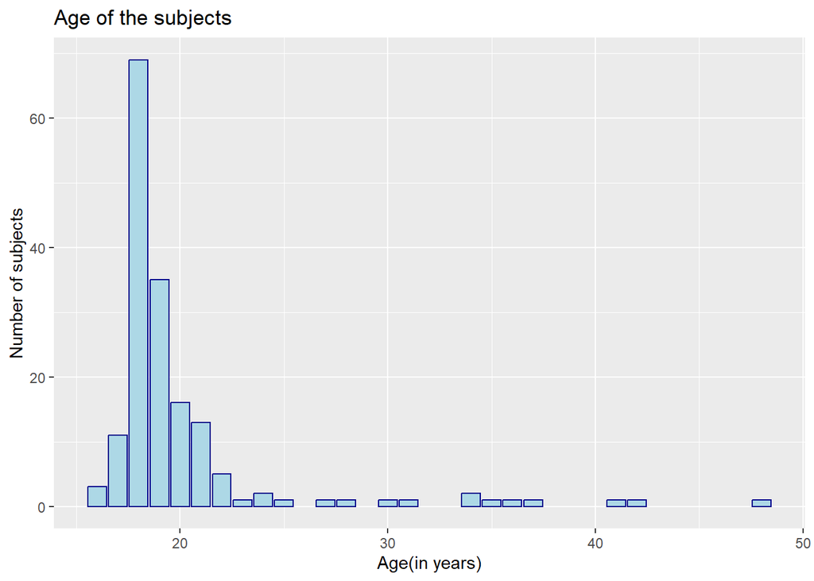

```r
ggplot(data = hiphop_demographics) +
  geom_bar( mapping = aes(x = age),
            color = "dark blue",
            fill="light blue"
            ) +
  labs( y = "Number of subjects",
        x = "Age(in years)",
        title = "Age of the subjects")
```

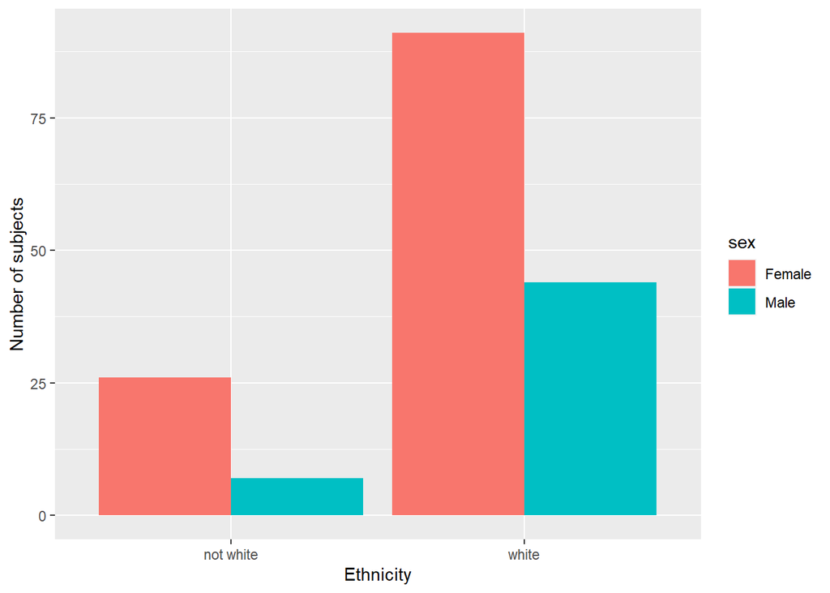

```r
#source = https://stackoverflow.com/questions/24895575/ggplot2-bar-plot-with-two-categorical-variables
# learned of the position argument for side-by-side bargraphs

ggplot(data = hiphop_demographics) +
  geom_bar( mapping = aes(x = white,
                          fill = sex),
            position = "dodge") +
  labs( y = "Number of subjects",
        x = "Ethnicity")
```

## Familiar Words

```r
under20 <- hiphop_clean |>
  select(age, word, familiarity)|>
  filter(age<20) |>
  group_by(word) |>
  summarize(familiarity = mean(familiarity))

under20 |> slice_min(familiarity, n = 1)
```

```
# A tibble: 1 × 2
  word             familiarity
  <chr>                  <dbl>
1 catch the vapors        1.03
```

```r
under20 |> slice_max(familiarity, n = 1)
```

```
# A tibble: 1 × 2
  word         familiarity
  <chr>              <dbl>
1 off the hook        4.42
```

1. People below the age of 20
   1. Least known word: catch the vapors
   2. Most known word: off the hook

```r
non_white_women <- hiphop_clean |>
  select(white, sex, word, familiarity) |>
  filter(white =="not white", sex == "Female") |>
  group_by(word) |>
  summarize(familiarity = mean(familiarity))

non_white_women |> slice_max(familiarity, n = 1)
```

```
# A tibble: 1 × 2
  word    familiarity
  <chr>         <dbl>
1 feel me        4.19
```

```r
non_white_women |> slice_min(familiarity, n = 1)
```

```
# A tibble: 4 × 2
  word              familiarity
  <chr>                   <dbl>
1 break someone out           1
2 dukey rope                  1
3 plex                        1
4 rollie                      1
```

1. Non-white women
   1. Least known word was tied by four: dukey rope, plex, rollie and break someone out
   2. Most known word: feel me

```r
above_30_white_men <- hiphop_clean |>
  select(white, sex, age, word, familiarity) |>
  filter(white == "white", sex == "Male", age > 30) |>
  group_by(word) |>
  summarize(familiarity = mean(familiarity))

above_30_white_men |> slice_max(familiarity, n = 1)
```

```
# A tibble: 1 × 2
  word  familiarity
  <chr>       <dbl>
1 5-0           4.2
```

```r
above_30_white_men |> slice_min(familiarity, n = 1)
```

```
# A tibble: 25 × 2
   word              familiarity
   <chr>                   <dbl>
 1 ay yo trip                  1
 2 beezy                       1
 3 break someone out           1
 4 catch the vapors            1
 5 crossroads                  1
 6 crump                       1
 7 dap                         1
 8 dollar cab                  1
 9 domino                      1
10 duckets                     1
# … with 15 more rows
```

## Study Subjects

```r
hiphop_demographics |>
  filter(white == "white",
         sex == "Male",
         16 < age, age < 24, 10000 < city,
         city< 60000) |> slice_max(bieber, n=1)
```

```
# A tibble: 1 × 39
  word     subj  sex     age ethnic  city county  intl vocal class…¹  folk  rock
  <chr>    <chr> <chr> <dbl> <chr>  <dbl>  <dbl> <dbl> <dbl>   <dbl> <dbl> <dbl>
1 [to be]… p17   Male     18 white  56377 331582     0     1       0     0     1
# … with 27 more variables: country <dbl>, pop <dbl>, alternative <dbl>,
#   hiphop <dbl>, unclassifiable <dbl>, countyBlack <dbl>, jayz <dbl>,
#   barkley <dbl>, boondocks <dbl>, monique <dbl>, bieber <dbl>,
#   asianMove <dbl>, blackMove <dbl>, hispanicMove <dbl>, nativeMove <dbl>,
#   SAAMEMove <dbl>, whiteMove <dbl>, blackWeekly <dbl>, jayz1 <dbl>,
#   boondocks1 <dbl>, familiarity <dbl>, trial <dbl>, fam1 <dbl>,
#   popularityScore <dbl>, numPreferredArtists <dbl>, …
```

I believe person 17 is Justin Bieber because they are a white male age 18 from a city of 56, 377 people and they named 4 Justin Bieber songs on the spot. He could’ve forgotten one of his own songs, or pretended otherwise, but he got the most in of the individuals who fit the demographics.